# Autism & Language

Ethan Weed

2026-06-17

# Autism

## Leo Kanner

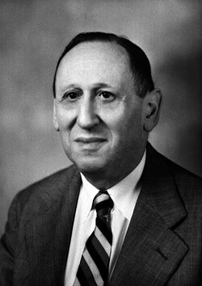

8 boys and 3 girls

Two essential features:

1. severe problems in social interaction and connectedness from the beginning of life
2. resistance to change or insistence on sameness.

## Leo Kanner

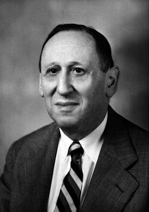

Also: **language** features such as

- echolalia
- pronoun reversal
- unusual prosody

## Hans Asperger

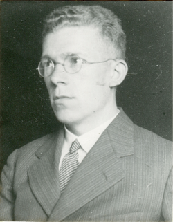

Described boys with marked social difficulties, unusual and particular interests, and **good verbal skills**

## Formal diagnosis

DSM-III (1980)

- Introduces three domains:
1. qualitative impairments in reciprocal social interaction
2. impairments in **communication**,
3. restricted interests/resistance to change and repetitive movements.

## Formal diagnosis

DSM-IV (1994)

- Sticks with the main three domains
- Many subcategories of Pervasive Developmental Disorders:
  - autistic disorder
  - Asperger’s disorder
  - Rett’s disorder
  - childhood disintegrative disorder
  - Pervasive Developmental Disorder not otherwise specified (PDD-NOS)

## Formal diagnosis

Problems with the DSM-IV

1. too much overlap betwen subcategories
2. hard to know which subcategory to diagnose
3. poor predictive power on later outcomes
4. restrictions on treatment eligibility based on subtcategory

## Formal diagnosis

DSM-V (2013): A more dimensional approach - subtypes are out

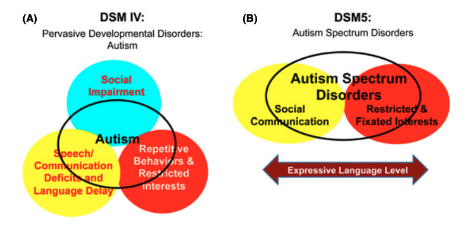

(Lord & Jones, 2012)

## Dimensions and categories

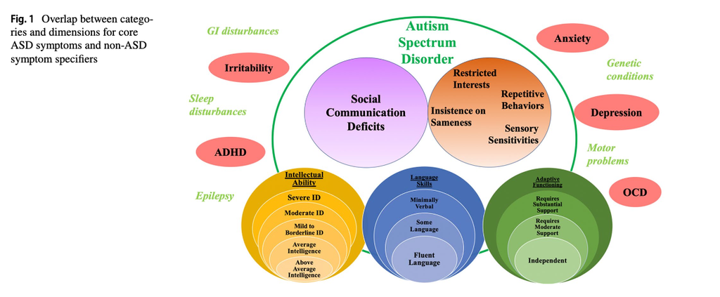

(Rosen et al., 2021)

## Prevalance

- 1970: 3 in 10,000 children (Treffert 1970) [.3 in 1000 children]
- 1999: 7 in 10,000 children (Fombonne 1999) [.7 in 1000 children]

## Prevalance

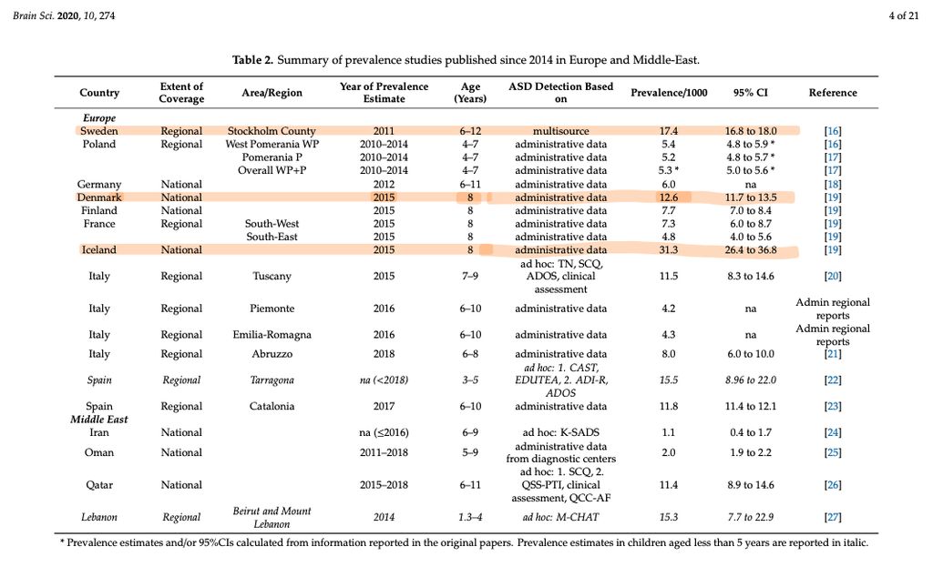

(Chiarotti & Venerosi, 2020)

## Prevalance

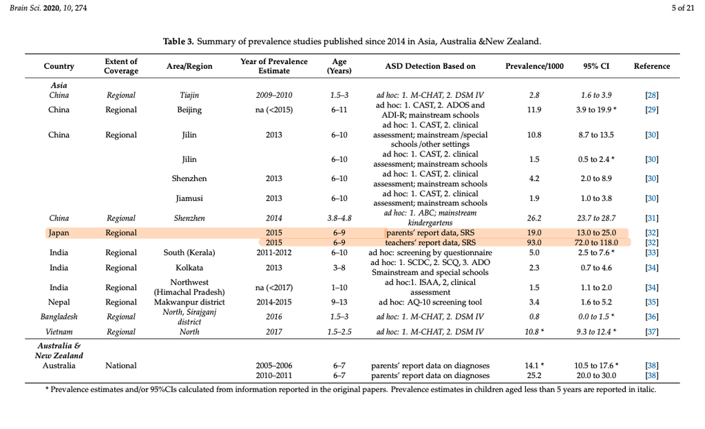

(Chiarotti & Venerosi, 2020)

## Prevalance

[figure not shown]

(Jensen De López & Thirup Møller, 2024)

## Research Interest

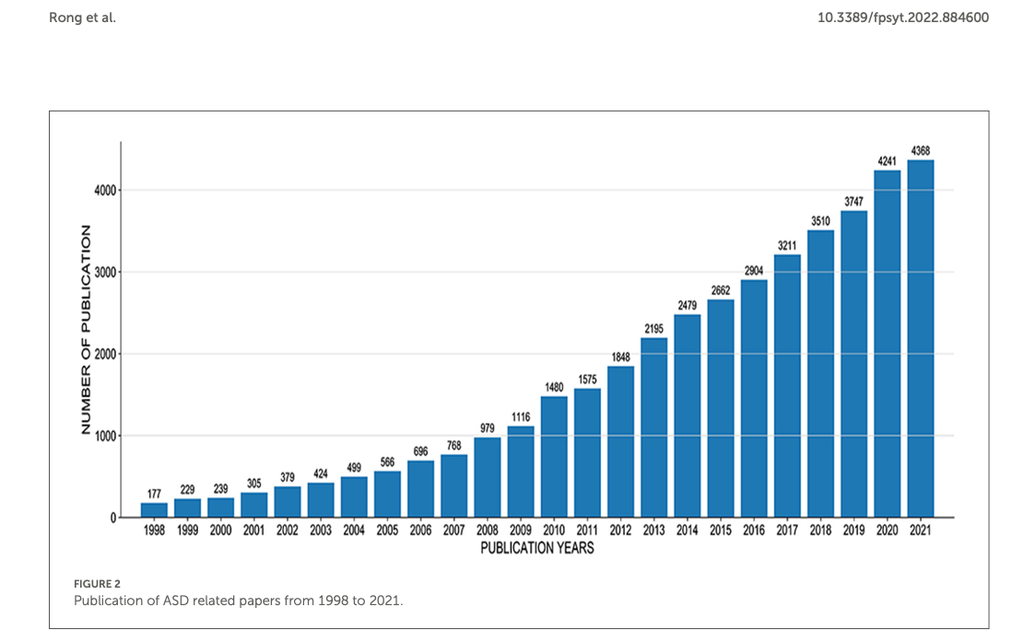

(Rong et al., 2022)

# Language

[figure not shown]

(de Saussure, n.d.)

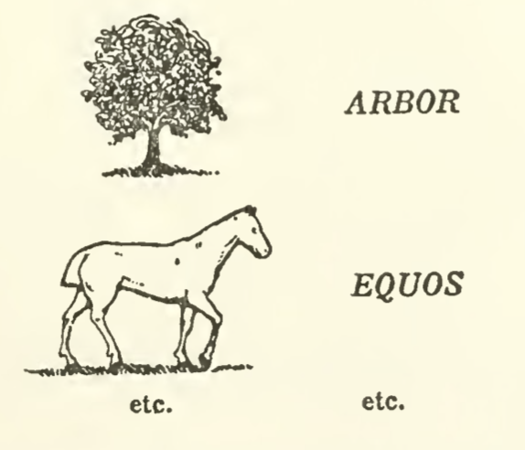

(de Saussure, n.d.)

- semantics
- morphology and syntax
- pragmatics (including prosody)

## Prosody 🎶

Three types of prosodic feature:

1. pitch
2. rhythm
3. timbre

Two types of acoustic feature:

1. source features (e.g. pitch, jitter)
2. temporal features (pauses, articulation rate, etc.)

# Autism and Language

## Pronoun Reversal

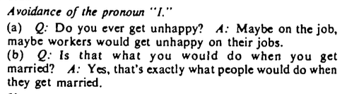

(Baltaxe, 1977)

## Foregrounding and Backgrounding of Information

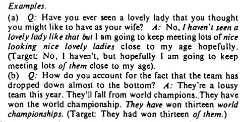

(Baltaxe, 1977)

### Atypical prosody

## Re-introducing context and nuance

## CONNECT project

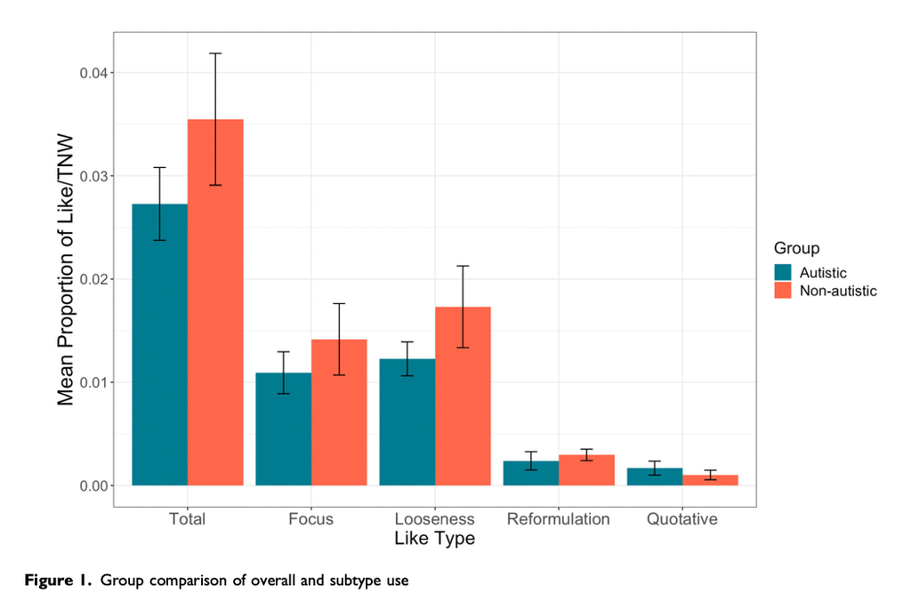

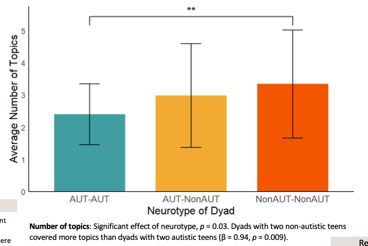

(Schillinger et al., n.d.)

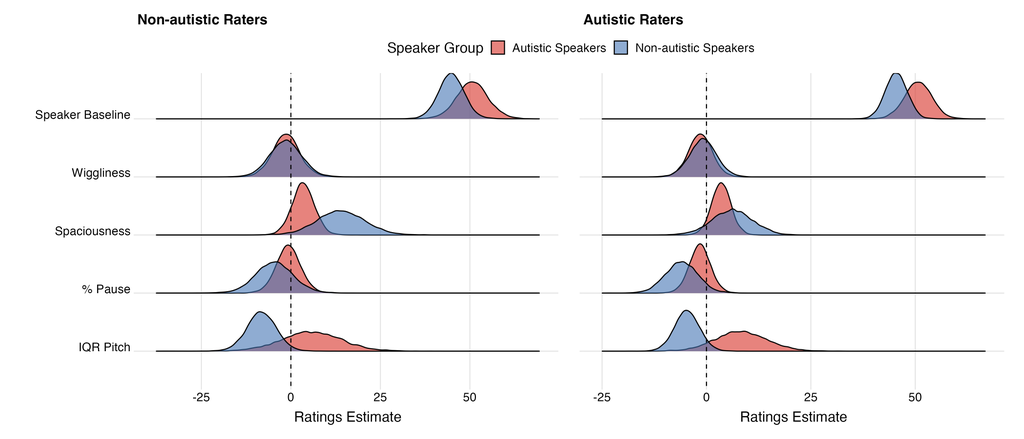

(Weed et al., 2026)

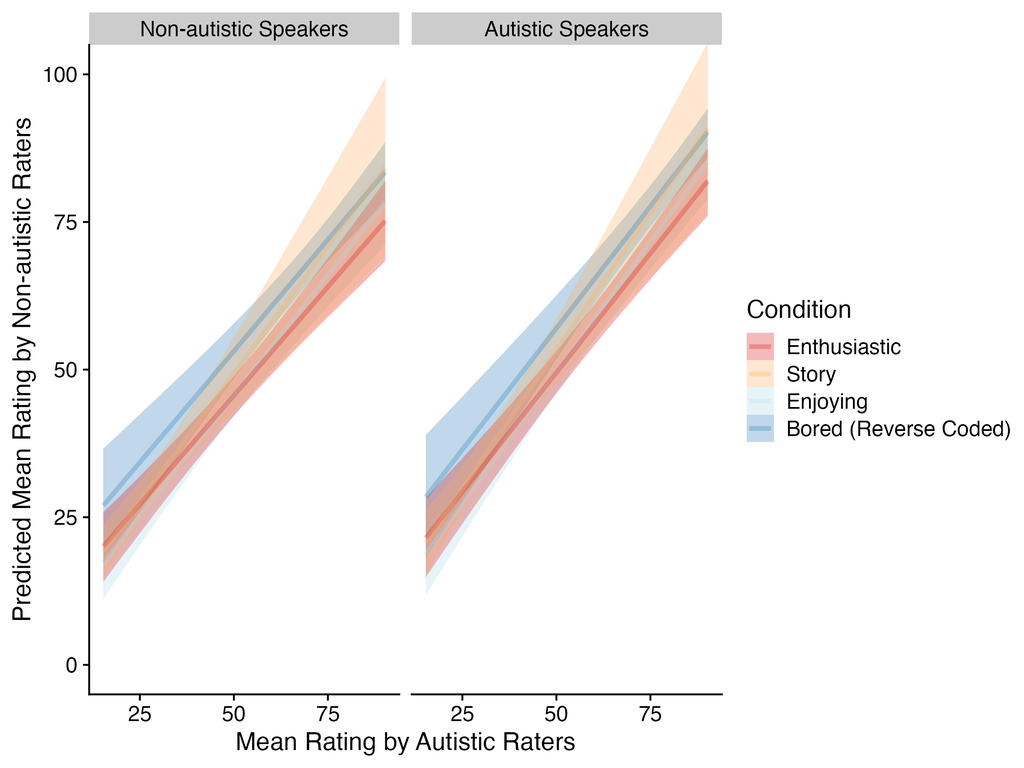

(Weed et al., 2026)

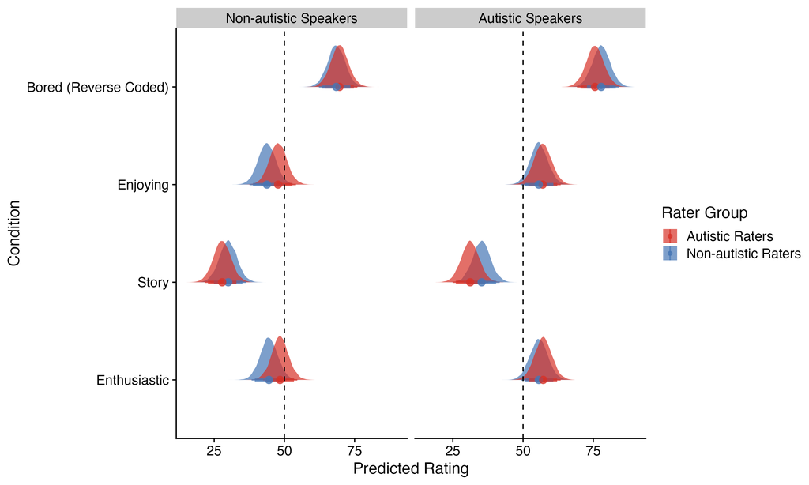

(Weed et al., 2026)

# References

## References

Baltaxe, C. A. M. (1977). Pragmatic Deficits in the Language of Autistic Adolescents. *Journal of Pediatric Psychology*, *2*(4), 176–180. https://doi.org/10.1093/jpepsy/2.4.176

Chiarotti, F., & Venerosi, A. (2020). Epidemiology of Autism Spectrum Disorders: A Review of Worldwide Prevalence Estimates Since 2014. *Brain Sciences*, *10*(5), 274. https://doi.org/10.3390/brainsci10050274

de Saussure, F. (n.d.). *Course in General Linguistics Ferdinand de Saussure* (E. C. Bally, A. Sechehaye, & A. Riedlinger, Eds.; W. Baskin, Tran.). McGraw-Hill.

Jensen De López, K., & Thirup Møller, H. (2024). Prevalence of Autism in Scandinavian Countries (Denmark, Norway, Sweden), and Nordic Countries (Finland, Iceland, the Faroe Islands, and Greenland). *Neuropsychiatric Disease and Treatment*, *Volume 20*, 1597–1612. https://doi.org/10.2147/NDT.S466081

Lord, C., & Jones, R. M. (2012). Annual Research Review: Re‐thinking the classification of autism spectrum disorders. *Journal of Child Psychology and Psychiatry*, *53*(5), 490–509. https://doi.org/10.1111/j.1469-7610.2012.02547.x

Rong, P., Fu, Q., Zhang, X., Liu, H., Zhao, S., Song, X., Gao, P., & Ma, R. (2022). A bibliometrics analysis and visualization of autism spectrum disorder. *Frontiers in Psychiatry*, *13*, 884600. https://doi.org/10.3389/fpsyt.2022.884600

Rosen, N. E., Lord, C., & Volkmar, F. R. (2021). The Diagnosis of Autism: From Kanner to DSM-III to DSM-5 and Beyond. *Journal of Autism and Developmental Disorders*, *51*(12), 4253–4270. https://doi.org/10.1007/s10803-021-04904-1

Schillinger, S., O’Connor, H., Groves, E., Franke, H., Abashidze, N., Petersons, C., Shen, S., Prescott, K., Cox, C., Weed, E., Fusaroli, R., Grossman, R., Parish-Morris, J., & Eigsti, I.-M. (n.d.). *“A Quick Hello”: Exploring Informal Self-Introductions of Autistic and Non-Autistic Adolescents over Zoom*.

Weed, E., Groves, E., Fusaroli, R., & Grossman, R. (2026). *Perceptual Consensus across Neurotypes: INSAR 2026*.